# COMPSCIX 415.2 Homework 3A

Rachel Hollowgrass

2/20/2018

```r
library(tidyverse)
```

### Section 3.8.1

**Exercise 1:** What is the problem with this plot? How could you improve it?

Many points are hiden because they are superimposed on each other. Using ‘jitter’ would show all of the points:

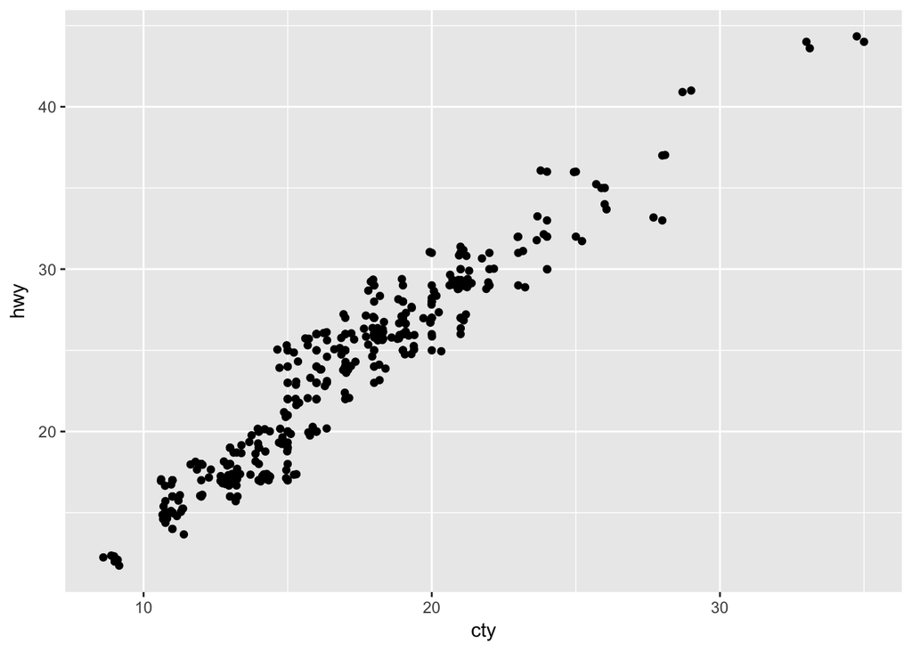

```r
ggplot(data = mpg, mapping = aes(x = cty, y = hwy)) +
  geom_point() +
  geom_jitter()
```

**Exercise 2:** What parameters to ‘geom_jitter()’ control the amount of jittering?

Using ‘geom_jitter(width = A, height = B)’ controls the jittering by amount ‘A’ and vertically by ‘B’.

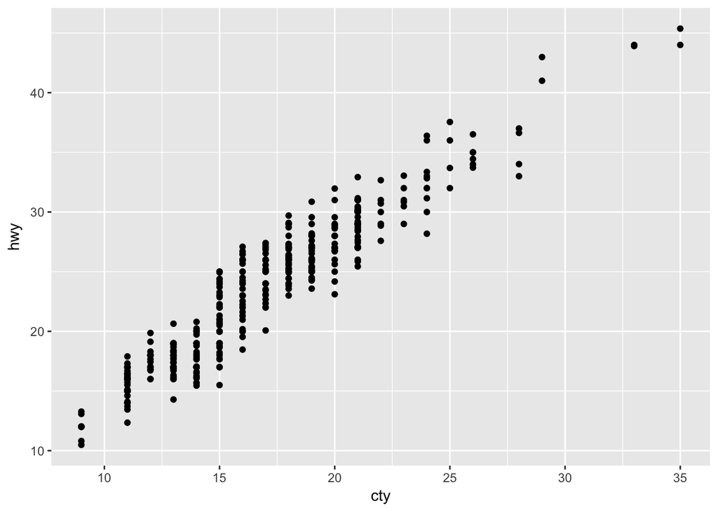

```r
ggplot(data = mpg, mapping = aes(x = cty, y = hwy)) +
  geom_point() +
  geom_jitter(width = 0, height = 2)
```

**Exercise 3:** Compare and contrast ‘geom_jitter()’ with ‘geom_count()’.

Both attempt to show how many points share coordinates. ‘geom_jitter()’ shows points sharing coordinate as clustered around those coordinates. ‘geom_count()’ does not offeset the points; instead, it shows a single point whose size represents the number of points that share those coordinates.

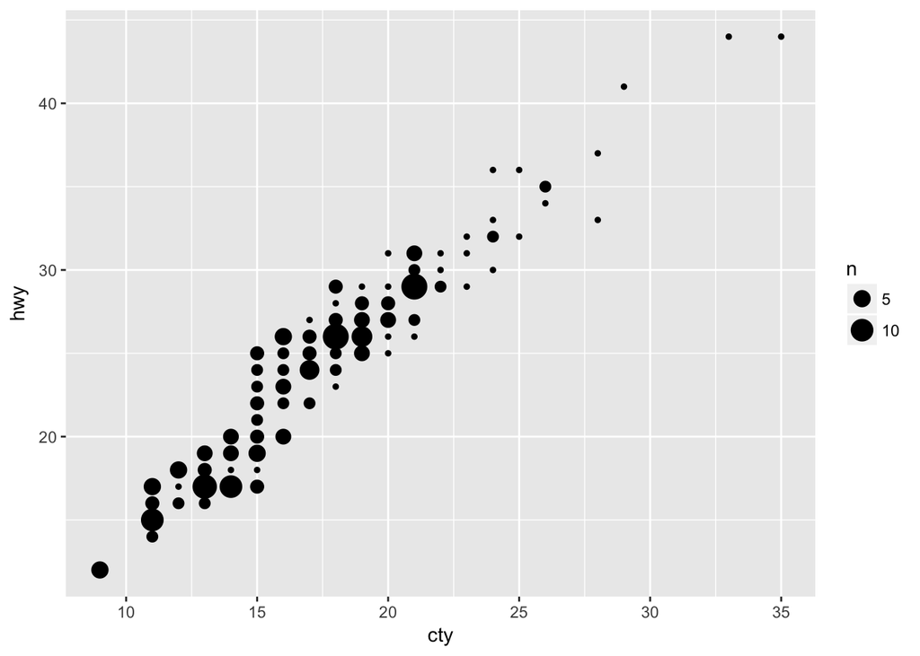

```r
ggplot(data = mpg, mapping = aes(x = cty, y = hwy)) +
  geom_count()
```

**Exercise 4:** What’s the default position adjustment for ‘geom_boxplot()’? Create a visualisation of the ‘mpg’ dataset that demonstrates it.

The first example below shows the default positioning for ‘geom_boxplot’. However, there do not appear to be any overlapping points, because ‘position_dodge’ does not reveal any.

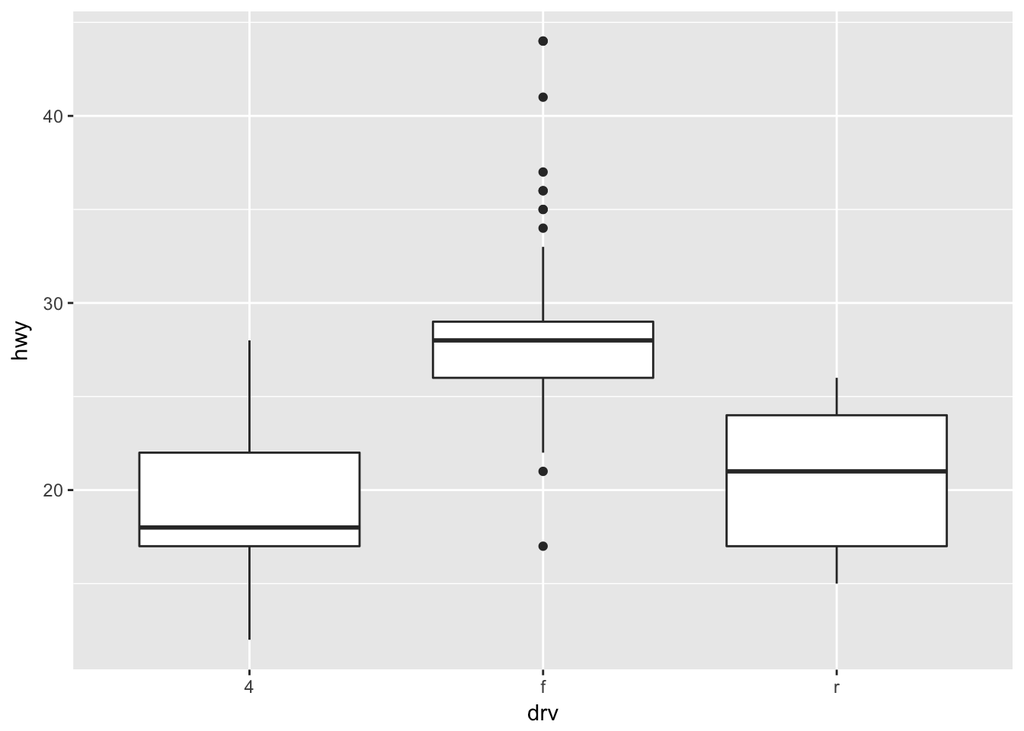

```r
ggplot(data = mpg, mapping = aes(x = drv, y = hwy)) +
  geom_boxplot()
```

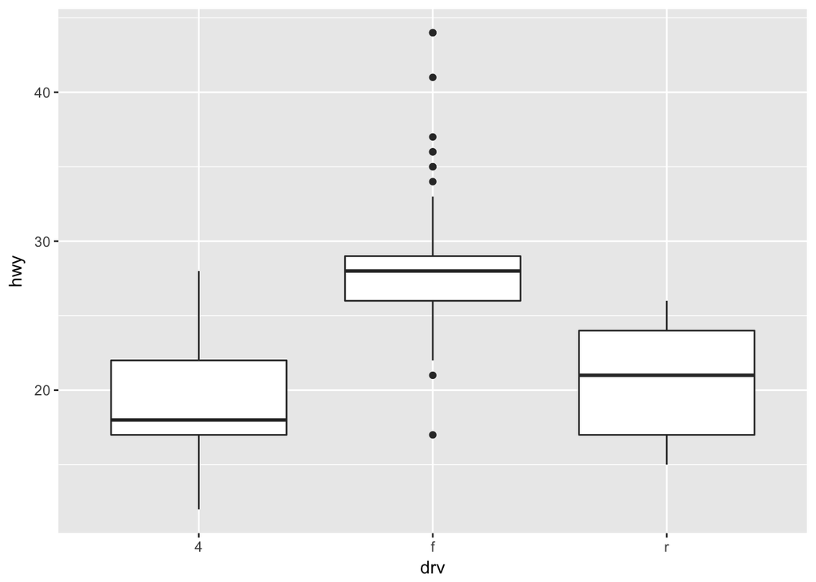

```r
ggplot(data = mpg, mapping = aes(x = drv, y = hwy)) +
  geom_boxplot(position = position_dodge(width = 2))
```